# IE6400 Foundations for Data Analytics Engineering

# Fall 2023

### Module 1: Introduction to the Visualization Analysis

#### Visualization Analysis in Python

Visualization analysis in Python refers to the process of examining data visually to understand it better and extract useful insights from it. It involves creating graphical representations of data, such as charts, graphs, and maps, to make it easier to identify patterns, trends, and outliers within large datasets. Visualization is an essential component of data analysis and data science, as it helps to communicate complex data in a clear and understandable manner.

#### Libraries for Visualization in Python:

1. **Matplotlib**: It is the most widely used data visualization library in Python. It allows for the creation of static, animated, and interactive visualizations in Python.
2. **Seaborn**: Built on top of Matplotlib, Seaborn is a statistical plotting library that provides a high-level interface for drawing attractive and informative statistical graphics.
3. **Plotly**: Plotly is a library that allows users to create interactive plots that can be embedded in web pages or used in data analysis.
4. **Bokeh**: Bokeh is another library for creating interactive and real-time streaming content.
5. **Pandas Plotting**: Pandas itself has built-in methods for data visualization. Each of these libraries has its own strengths and weaknesses, and the best one to use depends on the specific task and requirements.

### Seaborn

Seaborn is indeed a popular statistical data visualization library built on top of Matplotlib. It was developed to simplify and enhance the capabilities of Matplotlib, making it easier and quicker to create visually appealing and informative plots. Seaborn provides a high-level interface and various built-in functions for creating various statistical visualizations, making it more accessible to users, especially those working with complex datasets.

Key features of Seaborn include:

- Improved default styles: Seaborn comes with enhanced default styles and color palettes.
- High-level functions: Seaborn offers a set of high-level functions for creating common statistical plots. These functions often require less code compared to Matplotlib.
- Built-in statistical visualizations: Seaborn provides statistical plots that incorporate data analysis and visualization, such as regression plots, and kernel density estimation plots.
- Tight integration with Pandas: Seaborn is designed to work with Pandas DataFrames.
- Flexible customization

```python
!pip install seaborn
```

#### Exercise 1 Creating a Plot with Seaborn

The Seaborn library includes several datasets for testing data visualization and analysis skills. One of the most well-known collections is the "Titanic Dataset," which contains information about the passengers who were aboard the Titanic.

```python
import seaborn as sns
import matplotlib.pyplot as plt

titanic = sns.load_dataset("titanic")
titanic
```

|  | survived | pclass | sex | age | sibsp | parch | fare | embarked | class | who | adult_male | deck | embark_town | alive | alone |
| --- | --- | --- | --- | --- | --- | --- | --- | --- | --- | --- | --- | --- | --- | --- | --- |
| 0 | 0 | 3 | male | 22.0 | 1 | 0 | 7.2500 | S | Third | man | True | NaN | Southampton | no | False |
| 1 | 1 | 1 | female | 38.0 | 1 | 0 | 71.2833 | C | First | woman | False | C | Cherbourg | yes | False |
| 2 | 1 | 3 | female | 26.0 | 0 | 0 | 7.9250 | S | Third | woman | False | NaN | Southampton | yes | True |
| 3 | 1 | 1 | female | 35.0 | 1 | 0 | 53.1000 | S | First | woman | False | C | Southampton | yes | False |
| 4 | 0 | 3 | male | 35.0 | 0 | 0 | 8.0500 | S | Third | man | True | NaN | Southampton | no | True |
| ... | ... | ... | ... | ... | ... | ... | ... | ... | ... | ... | ... | ... | ... | ... | ... |
| 886 | 0 | 2 | male | 27.0 | 0 | 0 | 13.0000 | S | Second | man | True | NaN | Southampton | no | True |
| 887 | 1 | 1 | female | 19.0 | 0 | 0 | 30.0000 | S | First | woman | False | B | Southampton | yes | True |
| 888 | 0 | 3 | female | NaN | 1 | 2 | 23.4500 | S | Third | woman | False | NaN | Southampton | no | False |
| 889 | 1 | 1 | male | 26.0 | 0 | 0 | 30.0000 | C | First | man | True | C | Cherbourg | yes | True |
| 890 | 0 | 3 | male | 32.0 | 0 | 0 | 7.7500 | Q | Third | man | True | NaN | Queenstown | no | True |

891 rows × 15 columns

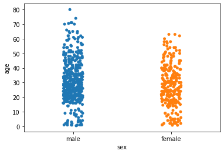

```python
import seaborn as sns
import matplotlib.pyplot as plt

titanic = sns.load_dataset("titanic")
sns.stripplot(data = titanic, x = "sex", y = "age")
plt.show()
```

The stripplot( ) function takes the two features in the dataset that we want to visualize. It is similar to the scatter plot, but they are often used when one variable is categorical instead of when both variables are continuous.

- You may notice that when producing visualizations with Seaborn, labels within your dataframe are applied to their respective categories.
- This is an improvement over Matplotlib, as it was required that you manually labeled the X-axis with your desired labels.
- You must make sure that your dataframe should have clearly defined column names with spcified datatypes.

#### Exercise 2 Figure Scaling

You can adjust the size of plots to fit various presentation settings with Seaborn. Additionally, Seaborn provides the option to change the "context" of a plot, which can modify its size and shape to suit different presentation formats better.

For example, you can set the context for notebooks, conference talks, or papers. This is an example of figure customization.

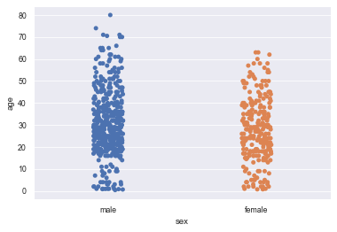

```python
import seaborn as sns
import matplotlib.pyplot as plt

titanic = sns.load_dataset("titanic")

sns.set(context = "paper")

sns.stripplot(data = titanic, x = "sex", y = "age")
plt.show()
```

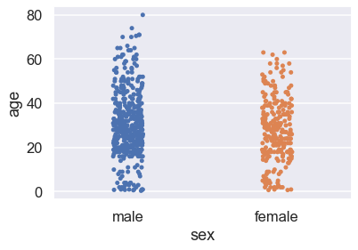

```python
import seaborn as sns
import matplotlib.pyplot as plt

titanic = sns.load_dataset("titanic")

sns.set(context = "talk")

sns.stripplot(data = titanic, x = "sex", y = "age")
plt.show()
```

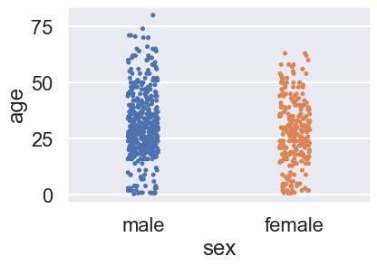

```python
import seaborn as sns
import matplotlib.pyplot as plt

titanic = sns.load_dataset("titanic")

sns.set(context = "poster")

sns.stripplot(data = titanic, x = "sex", y = "age")
plt.show()
```

#### Exercise 3 Plotting and Analyzing a Histogram

In this exercise, we will create a histogram of the frequency of diamonds in the dataset with their respective carat specifications on the x-axis:

```python
import seaborn as sns
import pandas as pd

diamonds_df = sns.load_dataset('diamonds')

diamonds_df
```

|  | carat | cut | color | clarity | depth | table | price | x | y | z |
| --- | --- | --- | --- | --- | --- | --- | --- | --- | --- | --- |
| 0 | 0.23 | Ideal | E | SI2 | 61.5 | 55.0 | 326 | 3.95 | 3.98 | 2.43 |
| 1 | 0.21 | Premium | E | SI1 | 59.8 | 61.0 | 326 | 3.89 | 3.84 | 2.31 |
| 2 | 0.23 | Good | E | VS1 | 56.9 | 65.0 | 327 | 4.05 | 4.07 | 2.31 |
| 3 | 0.29 | Premium | I | VS2 | 62.4 | 58.0 | 334 | 4.20 | 4.23 | 2.63 |
| 4 | 0.31 | Good | J | SI2 | 63.3 | 58.0 | 335 | 4.34 | 4.35 | 2.75 |
| ... | ... | ... | ... | ... | ... | ... | ... | ... | ... | ... |
| 53935 | 0.72 | Ideal | D | SI1 | 60.8 | 57.0 | 2757 | 5.75 | 5.76 | 3.50 |
| 53936 | 0.72 | Good | D | SI1 | 63.1 | 55.0 | 2757 | 5.69 | 5.75 | 3.61 |
| 53937 | 0.70 | Very Good | D | SI1 | 62.8 | 60.0 | 2757 | 5.66 | 5.68 | 3.56 |
| 53938 | 0.86 | Premium | H | SI2 | 61.0 | 58.0 | 2757 | 6.15 | 6.12 | 3.74 |
| 53939 | 0.75 | Ideal | D | SI2 | 62.2 | 55.0 | 2757 | 5.83 | 5.87 | 3.64 |

53940 rows × 10 columns

Plot a histogram using the diamonds dataset where x axis = carat:

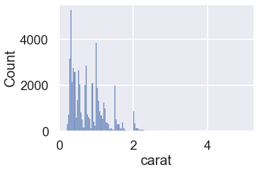

```python
import seaborn as sns
import pandas as pd

diamonds_df = sns.load_dataset('diamonds')
sns.histplot(diamonds_df.carat)
```

Change kde = True to show the KDE:

**Kernel Density Estimation (KDE)** is a statistical method used to estimate the probability density function of a continuous variable. It smoothens the distribution of data points by placing a kernel (usually a Gaussian function) on each data point and summing the contributions from all data points to create a smooth curve.

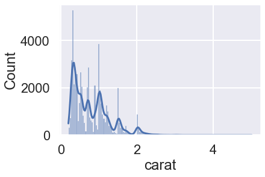

```python
sns.histplot(diamonds_df.carat, kde = True)
```

Increase the bins size to 100:

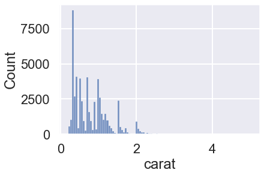

```python
sns.histplot(diamonds_df.carat, kde = False, bins = 100)
```

Use a log transformation on the histogram:

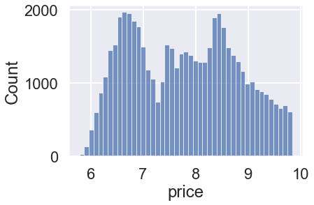

```python
import numpy as np
sns.histplot(np.log(diamonds_df.price), kde=False)
```

#### Exercise 4 Creating a Bar Plot and Calculating the Mean Price Distribution

In this exercise, we'll learn how to create a table using the pandas crosstab function. We'll use a table to generate a bar plot. We'll then explore a bar plot generated using the seaborn library and calculate the mean price distribution.

```python
import seaborn as sns
import pandas as pd

diamonds_df = sns.load_dataset('diamonds')
diamonds_df
```

|  | carat | cut | color | clarity | depth | table | price | x | y | z |
| --- | --- | --- | --- | --- | --- | --- | --- | --- | --- | --- |
| 0 | 0.23 | Ideal | E | SI2 | 61.5 | 55.0 | 326 | 3.95 | 3.98 | 2.43 |
| 1 | 0.21 | Premium | E | SI1 | 59.8 | 61.0 | 326 | 3.89 | 3.84 | 2.31 |
| 2 | 0.23 | Good | E | VS1 | 56.9 | 65.0 | 327 | 4.05 | 4.07 | 2.31 |
| 3 | 0.29 | Premium | I | VS2 | 62.4 | 58.0 | 334 | 4.20 | 4.23 | 2.63 |
| 4 | 0.31 | Good | J | SI2 | 63.3 | 58.0 | 335 | 4.34 | 4.35 | 2.75 |
| ... | ... | ... | ... | ... | ... | ... | ... | ... | ... | ... |
| 53935 | 0.72 | Ideal | D | SI1 | 60.8 | 57.0 | 2757 | 5.75 | 5.76 | 3.50 |
| 53936 | 0.72 | Good | D | SI1 | 63.1 | 55.0 | 2757 | 5.69 | 5.75 | 3.61 |
| 53937 | 0.70 | Very Good | D | SI1 | 62.8 | 60.0 | 2757 | 5.66 | 5.68 | 3.56 |
| 53938 | 0.86 | Premium | H | SI2 | 61.0 | 58.0 | 2757 | 6.15 | 6.12 | 3.74 |
| 53939 | 0.75 | Ideal | D | SI2 | 62.2 | 55.0 | 2757 | 5.83 | 5.87 | 3.64 |

53940 rows × 10 columns

```python
# Print the unique values of the cut column:
diamonds_df.cut.unique()
```

```
['Ideal', 'Premium', 'Good', 'Very Good', 'Fair']
Categories (5, object): ['Ideal', 'Premium', 'Good', 'Very Good', 'Fair']
```

```python
# Print the unique values of the clarity column:
diamonds_df.clarity.unique()
```

```
['SI2', 'SI1', 'VS1', 'VS2', 'VVS2', 'VVS1', 'I1', 'IF']
Categories (8, object): ['SI2', 'SI1', 'VS1', 'VS2', 'VVS2', 'VVS1', 'I1', 'IF']
```

unique( ) returns an array. There are five unique cut qualities and eight unique values in clarity.

To obtain the counts of diamonds of each cut quality, we first create a table using the pandas crosstab( ) function:

```python
cut_count_table = pd.crosstab(index = diamonds_df['cut'],
                              columns = 'count')
cut_count_table
```

| col_0 cut | count |
| --- | --- |
| Ideal | 21551 |
| Premium | 13791 |
| Very Good | 12082 |
| Good | 4906 |
| Fair | 1610 |

Plot the Bar Plot for these counts

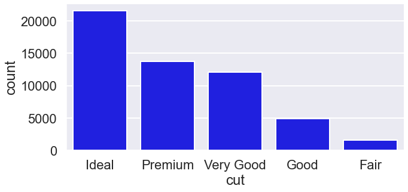

```python
sns.catplot(x = "cut",
            data = diamonds_df,
            aspect = 2.0,
            kind = "count",
            color = "blue")
```

Next, here is how we obtain the mean price distribution of different cut qualities using seaborn:

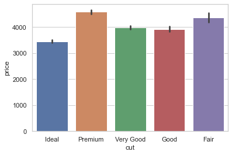

```python
import seaborn as sns
from numpy import median, mean
sns.set(style="whitegrid")
ax = sns.barplot(x = "cut",
                 y = "price",
                 data = diamonds_df,
                 estimator = mean)
```

Here, the black lines (error bars) on the rectangles indicate the uncertainty around the mean estimate. By default, this value is set to 95% confidence.

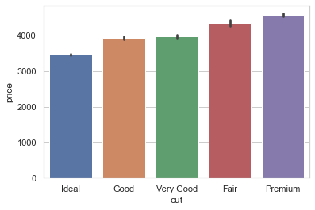

```python
ax = sns.barplot(x = "cut",
                 y = "price",
                 data = diamonds_df,
                 estimator = mean,
                 ci = 68,
                 order = ['Ideal','Good','Very Good','Fair','Premium'])
```

We changed the ci to 68%

#### Exercise 5 Creating Bar Plots Grouped by a Specific Feature

Now, we would like to look at the variation in each color:

```python
import seaborn as sns

diamonds_df = sns.load_dataset('diamonds')
diamonds_df
```

|  | carat | cut | color | clarity | depth | table | price | x | y | z |
| --- | --- | --- | --- | --- | --- | --- | --- | --- | --- | --- |
| 0 | 0.23 | Ideal | E | SI2 | 61.5 | 55.0 | 326 | 3.95 | 3.98 | 2.43 |
| 1 | 0.21 | Premium | E | SI1 | 59.8 | 61.0 | 326 | 3.89 | 3.84 | 2.31 |
| 2 | 0.23 | Good | E | VS1 | 56.9 | 65.0 | 327 | 4.05 | 4.07 | 2.31 |
| 3 | 0.29 | Premium | I | VS2 | 62.4 | 58.0 | 334 | 4.20 | 4.23 | 2.63 |
| 4 | 0.31 | Good | J | SI2 | 63.3 | 58.0 | 335 | 4.34 | 4.35 | 2.75 |
| ... | ... | ... | ... | ... | ... | ... | ... | ... | ... | ... |
| 53935 | 0.72 | Ideal | D | SI1 | 60.8 | 57.0 | 2757 | 5.75 | 5.76 | 3.50 |
| 53936 | 0.72 | Good | D | SI1 | 63.1 | 55.0 | 2757 | 5.69 | 5.75 | 3.61 |
| 53937 | 0.70 | Very Good | D | SI1 | 62.8 | 60.0 | 2757 | 5.66 | 5.68 | 3.56 |
| 53938 | 0.86 | Premium | H | SI2 | 61.0 | 58.0 | 2757 | 6.15 | 6.12 | 3.74 |
| 53939 | 0.75 | Ideal | D | SI2 | 62.2 | 55.0 | 2757 | 5.83 | 5.87 | 3.64 |

53940 rows × 10 columns

Use the hue parameter to plot nested groups:

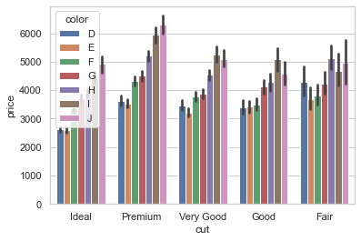

```python
ax = sns.barplot(x = "cut",
                 y = "price",
                 hue = 'color',
                 data = diamonds_df)
```

Place the legend on the Bar Plot:

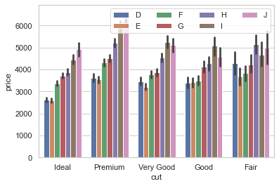

```python
ax = sns.barplot(x = "cut",
                 y = "price",
                 hue = 'color',
                 data = diamonds_df)

ax.legend(loc = 'upper right',
          ncol = 4)
```

- The ncol parameter denotes the number of columns into which values in the legend are to be organized
- The loc parameter specifies the location of the legend and can take any one of eight values (upper left, lower center, and so on).

To modify the axis labels on the x axis and y axis, input the following code:

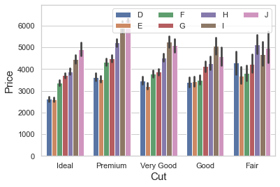

```python
ax = sns.barplot(x = "cut",
                 y = "price",
                 hue = 'color',
                 data = diamonds_df)

ax.legend(loc = 'upper right',
          ncol = 4)

ax.set_xlabel('Cut',
              fontdict = {'fontsize' : 15})

ax.set_ylabel('Price',
              fontdict = {'fontsize' : 15})
```

Similarly, use this to modify the font-size and rotation of the x axis of the tick labels:

[output not shown]

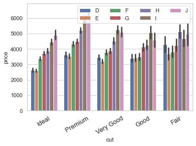

```python
ax = sns.barplot(x = "cut",
                 y = "price",
                 hue = 'color',
                 data = diamonds_df)

ax.legend(loc = 'upper right',
          ncol = 4)

# set fontsize and rotation of x-axis tick labels
ax.set_xticklabels(ax.get_xticklabels(),
                   fontsize = 13,
                   rotation = 30)
```

#### Exercise 6 Annotating a Bar Plot

```python
import matplotlib.pyplot as plt
import seaborn as sns

diamonds_df = sns.load_dataset('diamonds')
diamonds_df
```

|  | carat | cut | color | clarity | depth | table | price | x | y | z |
| --- | --- | --- | --- | --- | --- | --- | --- | --- | --- | --- |
| 0 | 0.23 | Ideal | E | SI2 | 61.5 | 55.0 | 326 | 3.95 | 3.98 | 2.43 |
| 1 | 0.21 | Premium | E | SI1 | 59.8 | 61.0 | 326 | 3.89 | 3.84 | 2.31 |
| 2 | 0.23 | Good | E | VS1 | 56.9 | 65.0 | 327 | 4.05 | 4.07 | 2.31 |
| 3 | 0.29 | Premium | I | VS2 | 62.4 | 58.0 | 334 | 4.20 | 4.23 | 2.63 |
| 4 | 0.31 | Good | J | SI2 | 63.3 | 58.0 | 335 | 4.34 | 4.35 | 2.75 |
| ... | ... | ... | ... | ... | ... | ... | ... | ... | ... | ... |
| 53935 | 0.72 | Ideal | D | SI1 | 60.8 | 57.0 | 2757 | 5.75 | 5.76 | 3.50 |
| 53936 | 0.72 | Good | D | SI1 | 63.1 | 55.0 | 2757 | 5.69 | 5.75 | 3.61 |
| 53937 | 0.70 | Very Good | D | SI1 | 62.8 | 60.0 | 2757 | 5.66 | 5.68 | 3.56 |
| 53938 | 0.86 | Premium | H | SI2 | 61.0 | 58.0 | 2757 | 6.15 | 6.12 | 3.74 |
| 53939 | 0.75 | Ideal | D | SI2 | 62.2 | 55.0 | 2757 | 5.83 | 5.87 | 3.64 |

53940 rows × 10 columns

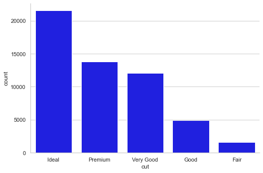

```python
# Generate a bar plot using catplot function of the seaborn library:
ax = sns.catplot(x = "cut",
                 data = diamonds_df,
                 aspect = 1.5,
                 kind = "count",
                 color = "blue")
```

Annotate the column belonging to the Ideal category:

```python
# get records in the DataFrame corresponding to ideal cut
ideal_group = diamonds_df.loc[diamonds_df['cut']=='Ideal']

# get the location of x coordinate where the annotation has to be placed
x = ideal_group.index.tolist()[0]

# get the location of y coordinate where the annotation has to be placed
y = len(ideal_group)

# print the x and y co-ordinates:
print(x)
print(y)
```

```
0
21551
```

Next, we will annotate the plot with a note:

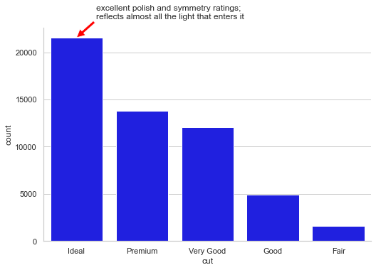

```python
# annotate the plot with any note or extra information

# Generate a bar plot using catplot function of the seaborn library:
ax = sns.catplot(x = "cut",
                 data = diamonds_df,
                 aspect = 1.5,
                 kind = "count",
                 color = "blue")

plt.annotate('excellent polish and symmetry ratings;\nreflects almost all the light that enters it',
             xy = (x,y),
             xytext = (x + 0.3, y + 2000),
             arrowprops = dict(facecolor = 'red'))

plt.show()
```

This code is a part of Matplotlib library in Python, used for annotating a point (x, y) on a plot. Let's break down the components:

**plt.annotate():** This function is used to annotate the point xy with the text.

- text: The first parameter is the text that will be used for annotation. In this case, it's a string explaining that the point represents excellent polish and symmetry ratings.
- xy: This parameter is a tuple representing the coordinates of the point that you want to annotate. (x, y) are the coordinates of the point to be annotated.
- xytext: This parameter is a tuple representing the coordinates where the annotation text will be placed on the plot. In this case, the text will be placed slightly to the right (x + 0.3) and above (y + 2000) the annotated point.
- arrowprops: This parameter is used to draw an arrow from the text to the point. The facecolor is set to 'red', meaning the arrow will be red in color.

So, this code will place an annotation with a red arrow on a plot, pointing from the text to a specific point (x, y), and the text will explain that the point represents excellent polish and symmetry ratings.

#### Exercise 7 Plot a Horizontal Bar Plot in Seaborn

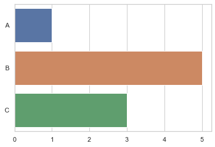

```python
import seaborn as sns

x = ['A', 'B', 'C']
y = [1, 5, 3]

sns.barplot(x = y,
            y = x)
plt.show()
```

Going back to the titanic dataset:

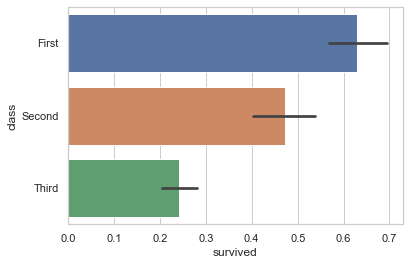

```python
import seaborn as sns
import matplotlib.pyplot as plt

titanic = sns.load_dataset("titanic")
sns.barplot(x = 'survived',
           y = 'class',
           data = titanic)
plt.show()
```

#### Exercise 8 Creating a Static Scatter Plot

In this exercise, we will generate a scatter plot to show the relationship between weight and mileage (mpg) of the vehicles from the mpg dataset. To do so, let's go through the following steps:

```python
import seaborn as sns
mpg_df = sns.load_dataset("mpg")
mpg_df.head()
```

|  | mpg | cylinders | displacement | horsepower | weight | acceleration | model_year | origin | name |
| --- | --- | --- | --- | --- | --- | --- | --- | --- | --- |
| 0 | 18.0 | 8 | 307.0 | 130.0 | 3504 | 12.0 | 70 | usa | chevrolet chevelle malibu |
| 1 | 15.0 | 8 | 350.0 | 165.0 | 3693 | 11.5 | 70 | usa | buick skylark 320 |
| 2 | 18.0 | 8 | 318.0 | 150.0 | 3436 | 11.0 | 70 | usa | plymouth satellite |
| 3 | 16.0 | 8 | 304.0 | 150.0 | 3433 | 12.0 | 70 | usa | amc rebel sst |
| 4 | 17.0 | 8 | 302.0 | 140.0 | 3449 | 10.5 | 70 | usa | ford torino |

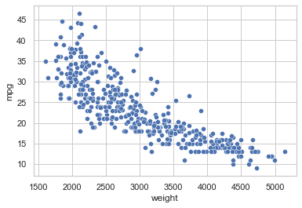

```python
# Generate a scatter plot using the scatterplot() function:
ax = sns.scatterplot(x = "weight",
                     y = "mpg",
                     data = mpg_df)
```

Notice that the scatter plot shows a decline in mileage (mpg) with an increase in weight.

#### Exercise 9 Creating a Static Hexagonal Binning Plot

In this exercise, we will generate a hexagonal binning plot to get a better understanding of the relationship between weight and mileage (mpg). Let's go through the following steps:

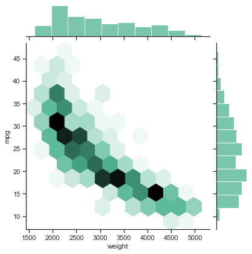

```python
import seaborn as sns

mpg_df = sns.load_dataset("mpg")

## set the plot style to include ticks on the axes.
sns.set(style="ticks")
## hexbin plot
sns.jointplot(x = mpg_df.weight,
              y = mpg_df.mpg,
              kind = "hex",
              color = "#4CB391")
```

#### Exercise 10 Creating a Static Contour Plot

In this exercise, we'll create a contour plot to show the relationship between weight and mileage in the mpg dataset. We'll be able to see that the relationship between weight and mileage is strongest when there are more data points. Let's go through the following steps:

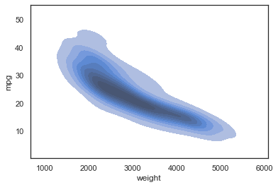

```python
import seaborn as sns

mpg_df = sns.load_dataset("mpg")

# Contour plot
sns.set_style("white")
# Generate KDE plot
sns.kdeplot(x = mpg_df.weight,
            y = mpg_df.mpg,
            shade = True)
```

Notice that the interpretation of contour plots is similar to that of hexbin plots – darker regions indicate more data points and lighter regions indicate fewer data points.

#### Exercise 11 Creating a Static Line Plot

In this exercise, we will create a scatter plot for a different pair of features, model_year and mpg. Then, we'll generate a line plot based on those discrete attributes – model_year and mpg. To do so, let's go through the following steps:

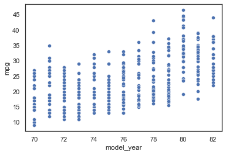

```python
import seaborn as sns

mpg_df = sns.load_dataset("mpg")
# contour plot
sns.set_style("white")
# seaborn 2-D scatter plot
ax1 = sns.scatterplot(x = "model_year",
                      y = "mpg",
                      data = mpg_df)
```

In this example, we see that the model_year feature only takes discrete values between 70 and 82. Now, when we have a discrete numerical feature like this (model_year), drawing a line plot joining the data points is a good idea. We can draw a simple line plot showing the relationship between model_year and mileage with the following code.

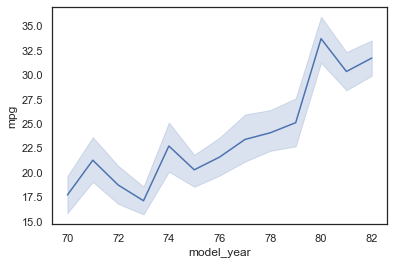

```python
# Draw a simple line plot to show the relationship between model_year
# and mileage:
ax = sns.lineplot(x = "model_year",
                  y = "mpg",
                  data = mpg_df)
```

As we can see, the points connected by the solid line represent the mean of the y axis feature at the corresponding x coordinate. The shaded area around the line plot shows the confidence interval for the y axis feature (by default, seaborn sets this to a 95% confidence interval).

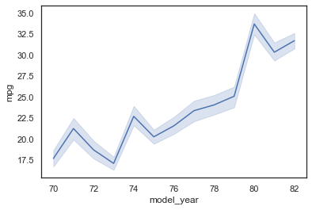

```python
# Change the confidence interval to 68
sns.lineplot(x = "model_year",
             y = "mpg",
             data = mpg_df,
             ci = 68)
```

#### Exercise 12 Presenting Data across Time with multiple Line Plots

In this example, we'll see how to present data across time with multiple line plots. We are using the flights dataset:

```python
import seaborn as sns

flights_df = sns.load_dataset("flights")
flights_df.head()
```

|  | year | month | passengers |
| --- | --- | --- | --- |
| 0 | 1949 | Jan | 112 |
| 1 | 1949 | Feb | 118 |
| 2 | 1949 | Mar | 132 |
| 3 | 1949 | Apr | 129 |
| 4 | 1949 | May | 121 |

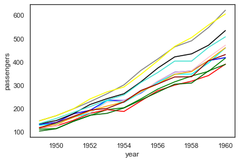

```python
# line plots for the planets dataset
ax = sns.lineplot(x="year", y="passengers", data=flights_df[flights_df['month']=='Jan'], color='green')
ax = sns.lineplot(x="year", y="passengers", data=flights_df[flights_df['month']=='Feb'], color='red')
ax = sns.lineplot(x="year", y="passengers", data=flights_df[flights_df['month']=='Mar'], color='blue')
ax = sns.lineplot(x="year", y="passengers", data=flights_df[flights_df['month']=='Apr'], color='cyan')
ax = sns.lineplot(x="year", y="passengers", data=flights_df[flights_df['month']=='May'], color='pink')
ax = sns.lineplot(x="year", y="passengers", data=flights_df[flights_df['month']=='Jun'], color='black')
ax = sns.lineplot(x="year", y="passengers", data=flights_df[flights_df['month']=='Jul'], color='grey')
ax = sns.lineplot(x="year", y="passengers", data=flights_df[flights_df['month']=='Aug'], color='yellow')
ax = sns.lineplot(x="year", y="passengers", data=flights_df[flights_df['month']=='Sep'], color='turquoise')
ax = sns.lineplot(x="year", y="passengers", data=flights_df[flights_df['month']=='Oct'], color='orange')
ax = sns.lineplot(x="year", y="passengers", data=flights_df[flights_df['month']=='Nov'], color='darkgreen')
ax = sns.lineplot(x="year", y="passengers", data=flights_df[flights_df['month']=='Dec'], color='darkred')
```

Creating line plots for each month in the flights_df DataFrame, plotting year against passengers. The code can be made more concise and efficient by using a loop to iterate over the months and colors, rather than repeating the sns.lineplot() function for each month. Below is the revised version of the code:

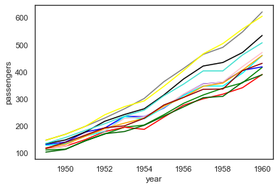

```python
import seaborn as sns
flights_df = sns.load_dataset("flights")

# List of months and corresponding colors
months = ['Jan', 'Feb', 'Mar', 'Apr', 'May', 'Jun', 'Jul', 'Aug', 'Sep', 'Oct', 'Nov', 'Dec']
colors = ['green', 'red', 'blue', 'cyan', 'pink', 'black', 'grey', 'yellow', 'turquoise', 'orange',
          'darkgreen', 'darkred']

# Iterating over months and colors to create line plots
for month, color in zip(months, colors):
    ax = sns.lineplot(
        x="year",
        y="passengers",
        data=flights_df[flights_df['month'] == month],
        color=color
    )
```

This approach reduces redundancy and makes the code more maintainable and readable.

#### Exercise 13 Creating and Exploring a Static Heatmap

In this exercise, we will explore and create a heatmap. We will use the flights dataset from the seaborn library to generate a heatmap depicting the number of passengers per month across the years 1949-1960:

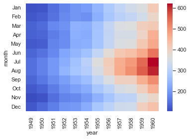

```python
import seaborn as sns
import matplotlib.pyplot as plt

flights_df = sns.load_dataset('flights')
df_pivoted = flights_df.pivot("month", "year", "passengers")
ax = sns.heatmap(df_pivoted, cmap = 'coolwarm')
plt.show()
```

```python
df_pivoted
```

| year month | 1949 | 1950 | 1951 | 1952 | 1953 | 1954 | 1955 | 1956 | 1957 | 1958 | 1959 | 1960 |
| --- | --- | --- | --- | --- | --- | --- | --- | --- | --- | --- | --- | --- |
| Jan | 112 | 115 | 145 | 171 | 196 | 204 | 242 | 284 | 315 | 340 | 360 | 417 |
| Feb | 118 | 126 | 150 | 180 | 196 | 188 | 233 | 277 | 301 | 318 | 342 | 391 |
| Mar | 132 | 141 | 178 | 193 | 236 | 235 | 267 | 317 | 356 | 362 | 406 | 419 |
| Apr | 129 | 135 | 163 | 181 | 235 | 227 | 269 | 313 | 348 | 348 | 396 | 461 |
| May | 121 | 125 | 172 | 183 | 229 | 234 | 270 | 318 | 355 | 363 | 420 | 472 |
| Jun | 135 | 149 | 178 | 218 | 243 | 264 | 315 | 374 | 422 | 435 | 472 | 535 |
| Jul | 148 | 170 | 199 | 230 | 264 | 302 | 364 | 413 | 465 | 491 | 548 | 622 |
| Aug | 148 | 170 | 199 | 242 | 272 | 293 | 347 | 405 | 467 | 505 | 559 | 606 |
| Sep | 136 | 158 | 184 | 209 | 237 | 259 | 312 | 355 | 404 | 404 | 463 | 508 |
| Oct | 119 | 133 | 162 | 191 | 211 | 229 | 274 | 306 | 347 | 359 | 407 | 461 |
| Nov | 104 | 114 | 146 | 172 | 180 | 203 | 237 | 271 | 305 | 310 | 362 | 390 |
| Dec | 118 | 140 | 166 | 194 | 201 | 229 | 278 | 306 | 336 | 337 | 405 | 432 |

Here, we can note that the total number of yearly flights increased steadily from 1949 to 1960. Moreover, the months of July and August seem to have the largest number of flights (compared to other months) across the years in observation.